# Rmarkdown for Term Paper and Course Wrap-up

## 1.3 References in R Markdown

One of the questions I have received frequently for the term papers is how to do citations in R Markdown. In fact, it is quite easy. All you need is a **bibtex** file and a proper syntax for referencing. This format is a simple text file which you can open with any text editor, and it is the bibliography manager for LaTeX documents. However, you can also use it with other formats such as markdown files.

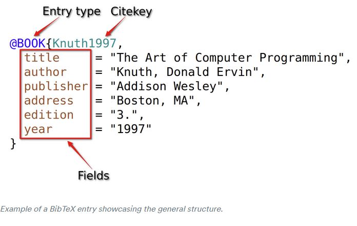

You all know google scholar. When you search for an article there, you can copy the article reference information in a bibtex format and include them in your `.bib` file. In the folder “2024_01_31_Session14”, you see a file called `references.bib`, here is what we keep our bibtex entries.

[figure not shown]

These bibentries have a citation key. We use those keys for referencing in the text. Also, as you know we have different citation styles such as MLA, APA, Chicago. To use different styles, you can download their csl file from [here](https://www.zotero.org/styles).

Or you can simply do the referencing the way you would do it in a Word Document.

## 1.4 Beautifying your R Markdown output

You might not be very happy with the html output you get. The good news is that there are other themes you can use either from the rmarkdown package itself or some extra packages.

R Markdown provides a wide range of built-in themes, such as “simplex,” “slate,” “flatly,” “darkly,” and many more. Each theme has its own unique visual characteristics, allowing you to choose a style that best suits your content or purpose. Basically, you can using R Markdown themes from base R, you don’t need for install any packages for that. But, when you want some extra. Here is some packages you can use for customize the themes: rmdformats, prettydoc, hrbrthemes.

**Procrastination tip**: Some of the themes you can give by default are: “default”, “bootstrap”, “cerulean”, “cosmo”, “darkly”, “flatly”, “journal”, “lumen”, “paper”, “readable”, “sandstone”, “simplex”, “spacelab”, “united”, “yeti”. You can specify the theme in your YAML `theme: cosmo`

## 1.5 Deliverables for term paper

If you are writing your term paper in R Markdown or Quarto (which I think most of you do), it is very important for me to be able to run your code and get to the same results that you did. Therefore, it might be easiest for you to create your term paper as a project in R, containing all data in there (don’t forget about good folder structure such as separate folders for data, plots, etc. inside the same project folder). Therefore, please include your RMarkdown, in addition to the html our pdf output you get after knitting the document. That being said, the deliverables are:

- R Markdown script
- Html or pdf output
- Data used
- All as one zipped file

## 1.6 Extra Notes

1. These slides are cool and also they have been made in R Markdown.

[Cool slides on R Markdown](https://resulumit.com/teaching/rmd_workshop.html#1)

2. To make your code more readable, it is always a good practice to give names to your code chunks like the following

```r
#inside {r} you can give a short name
```

3. Comment your codes. Most of the times, you think you will remember what you have done, but in reality, after a week or so, it is difficult to remember that :-) Also, having commented codes make your work more reproducible.
4. Set global parameters for your code chunks or set parameters individually on the code chunks. For instance specify whether the warnings shown in the final output, whether both your code and the outcome should be shown, or the outcome would suffice, etc.

```r
library(tidyverse)
```

The one below has a name (name comes directly after r) and also we set the parameter for the warning not to be shown. You can also set this parameter as a general one for the whole script. `knitr::opts_chunk$set(echo=FALSE, message=FALSE, warning=FALSE)`

```r
library(tidyverse)
```

# 2 This course

## 2.1 What you learned:

- A lot of functions from tidyverse for handling your data
- Some basics of webscraping, regular expressions, automatic annotation, data visualization, hierarchical structures such as html and xml

### 2.1.1 Most important functions in my opinion:

- Read and write your data in/from R (`read_csv()`, `write_tsv()`, `read_rds()`, etc. )
- Basic tidyverse functions: `mutate()`, `select()`, `filter()`, `rename()`, `arrange()`
- My two absolute favorites: `group-by()`, `summarise()`
- Very useful: `ifelse` sytax
- string cleaning and processing functions: `str_c()`, `paste0()`, `grepl()`, `str_detect()`, `str_extract()`, `str_remove()`, `str_replace()`
- Other useful ones: (1) merge and join functions, e.g., `merge()`, `left_join()`, `inner_join()`, (2) lag `lag()` and `lead()`, (3) `slice()`

## 2.2 What you did not learn :-(

- `for-loops` (I may write a short tutorial on it and put it on ilias). Learn for-loops but use them only when absolutely necessary. In above 90% of my coding, I do not need to use them (there are alternative, easier solutions usually).
- Manual annotation: I would’ve loved to talk a bit about my favorite manual annotation software for textual data (`WebAnno` and `INCEpTION`). They are very easy to use and there are good youtube videos on their functionalities.
- How to query available existing corpora using `sketch engine`. It is super useful and not too difficult to learn.
- My initial plan was to have the last 2-3 sessions to do purely linguistic analysis (similar to the text analysis we did today), such as cluster and correspondence analysis, lexical similarity analysis, concordancing, collocationa analysis, topic modeling. But it did not happen, as it took us a bit longer in the first couple of sessions. But at some point, I felt like it would be more useful to learn data processing in R on a more general level. If you learn useful functions, you can easily apply them to any type of data. And it is always enabling to be able to process your data, be it linguistic or non-linguistic. However, I really hope you will have more linguistically-focused courses with R in the future. In any case, there are a lot of resources you can use to learn different types of analysis. I introduced some in the second session of the course. Check the slides.

## 2.3 Some anecdote:

- In my opinion, the most important step in R programming is to bring your data into R. The rest happens :-)
- You heard about a lot of functions during this course. However, you won’t learn R (or any other programming language) until you get your hands dirty with coding. PLEASE DO NOT BE AFRAID OF IT! :-)
- Google knows everything! GPT might be sometimes dumb, but it also knows a lot. If you run into errors, instead of giving up, google them or ask ChatGPT.

## 2.4 Some notes on ChatGPT

- What I personally use ChatGPT for the most is debugging and grammar correction. My favorite short prompt `Correct grammar without changing my tone`.
- In my opinion, DO NOT use it too much for writing (emails, articles, or whatever else). In its current state, it’s still quite dumb. The language is not natural and it may affect the reader’s perspective of you :-) Oh! if you use it for writing, use it smartly (dedicate sometime to your prompting)!

# References

Grice, M., Baumann, S., and Benzmüller, R. (2006). Autosegmental-metrical phonology. *Prosodic Typology: The Phonology of Intonation and Phrasing*, 55–83.